# 2017 Census Income Per Capita presentation

## by Christopher James

## Investigation Overview

My goal with this analysis is to uncover the features that have large affects on per capita income.

## Dataset Overview

This dataset contains population, travel, work, and income information from the 2017 Census Bureau ACS survey. It contains state, census tract, and county statistics. It also contains poverty, income, transportation, job type, and unemployment statistics. There are 74,001 rows, one for each census tract.

## Relationship Between Per Capita Income and Unemployment Level

At first, it might seem surprising that there is not a stronger coorelation between unemployment numbers and per capita income. However, it could be that there are simply not that many tracts with high enough levels of unemployment to bring down the averages.

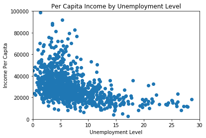

```python
# Plot per capita income by unemployment level.
plt.scatter(data = df_samp, x = 'Unemployment', y = 'IncomePerCap')
plt.xlabel('Unemployment Level')
plt.ylabel('Income Per Capita')
plt.title('Per Capita Income by Unemployment Level')
plt.xlim(left = 0, right = 30)
plt.ylim(bottom = 0, top = 100000);
```

## Relationhip Between Per Capita Income, Poverty, and Professional Job Levels.

Here, it is clear that per capita income is higher in places that have more professional jobs and lower levels of poverty. Even though the overall trend is clear, there appear to be plenty of places with lower poverty levels that have lower levels of incomes and professional jobs. In addition, places with high poverty seem to stagnate in the income department even with the increase in professional jobs.

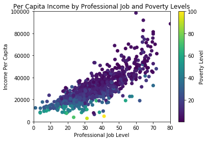

```python
# Plot per capita income broken down by poverty and professional job levels.
plt.scatter(data = df_samp, x = 'Professional', y = 'IncomePerCap', c = 'Poverty')
plt.xlabel('Professional Job Level')
plt.ylabel('Income Per Capita')
cbar = plt.colorbar()
cbar.set_label('Poverty Level')
plt.title('Per Capita Income by Professional Job and Poverty Levels')
plt.ylim(bottom = 0, top = 100000)
plt.xlim(left = 0, right = 80);
```

## Relationhip Between Per Capita Income, Poverty, and Production Job Levels.

Per capita income seems to benefit when there are less production jobs. As seen with professional jobs, places with the highest poverty levels are not affected by the level of production jobs.

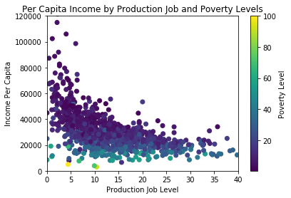

```python
# Plot per capita income broken down by poverty and production job levels.
plt.scatter(data = df_samp, x = 'Production', y = 'IncomePerCap', c = 'Poverty')
plt.xlabel('Production Job Level')
plt.ylabel('Income Per Capita')
cbar = plt.colorbar()
cbar.set_label('Poverty Level')
plt.title('Per Capita Income by Production Job and Poverty Levels')
plt.ylim(bottom = 0, top = 120000)
plt.xlim(left = 0, right = 40);
```

## Relationhip Between Per Capita Income, Poverty, and Service Job Levels.

Per capita income drops rapidly with just a fairly small increase in service jobs, then the decrease is much more mild after that. A pattern appears to be emerging that shows that per capita income in places with high poverty does not change no matter the job composition.

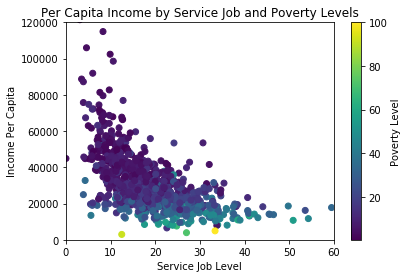

```python
# Plot per capita income broken down by poverty and service job levels.
plt.scatter(data = df_samp, x = 'Service', y = 'IncomePerCap', c = 'Poverty')
plt.xlabel('Service Job Level')
plt.ylabel('Income Per Capita')
cbar = plt.colorbar()
cbar.set_label('Poverty Level')
plt.title('Per Capita Income by Service Job and Poverty Levels')
plt.ylim(bottom = 0, top = 120000)
plt.xlim(left = 0, right = 60);
```